# Example: Roomba Lava World Task using Q-Learning

In this example, we will solve a grid-world navigation task using Q-learning. Here is the scenario:

**Scenario**: Suppose you have a robot vacuum cleaner, e.g., a [roomba](https://www.irobot.com), that has finished cleaning the kitchen floor and needs to return to its charging station. However, between your kitchen floor and the charging station (safety), there are one or more lava pits (destruction for the [roomba](https://www.irobot.com)). This two-dimensional grid-world navigation task (which is similar to the Markov Decision Process problem that we explored earlier) will familiarize students with using Q-learning for solving a sequential decision task in which we have **no model of the world!** Then how does the robot learn to navigate safely back to its charging station while avoiding the lava pits? The answer is through trial and error using a model-free reinforcement learning algorithm.

> **Learning Objectives:**

> After completing this activity, students will be able to:
> - **Understand Q-learning:** We explore the theoretical foundations of Q-learning. This model-free reinforcement learning algorithm learns optimal policies through trial and error by updating action-value estimates based on observed rewards.
> - **Implement Q-learning:** We build and execute a Q-learning agent that learns to navigate a grid world environment. The implementation shows how to construct the environment model, define reward structures, and train the agent through repeated episodes.
> - **Apply reward shaping techniques:** We use radial basis functions to shape sparse rewards, providing the agent with guidance signals that accelerate learning without requiring full knowledge of the optimal policy.

Let's get started! ___

## Setup, Data, and Prerequisites

First, we set up the computational environment by including the `Include.jl` file and loading any needed resources.

> The [`include(...)` command](https://docs.julialang.org/en/v1/base/base/#include) evaluates the contents of the input source file, `Include.jl`, in the notebook's global scope. The `Include.jl` file sets paths, loads required external packages, etc. For additional information on functions and types used in this material, see the [Julia programming language documentation](https://docs.julialang.org/en/v1/).

Let's set up our code environment:

```julia
include(joinpath(@__DIR__, "Include.jl")); # include the Include.jl file
```

In addition to standard Julia libraries, we'll also use [the `VLDataScienceMachineLearningPackage.jl` package](https://github.com/varnerlab/VLDataScienceMachineLearningPackage.jl). Check out [the documentation](https://varnerlab.github.io/VLDataScienceMachineLearningPackage.jl/dev/) for more information on the functions, types, and data used in this material.

### Implementation

We implement two helper functions for the Q-learning algorithm. The `rbf(...)` function computes the radial basis function kernel, which measures similarity between two grid positions. The `lavaworld(...)` function defines the environment dynamics, taking the current state and action as inputs and returning the next state and reward.

```julia
function rbf(x::Tuple{Int,Int},y::Tuple{Int,Int}; σ = 1.0)::Float64
    d = sqrt((x[1] - y[1])^2 + (x[2] - y[2])^2);
    return exp(-d/(2*σ^2))
end;
```

The `lavaworld(...)` function simulates one step in the environment. Given the current state `s::Int` and action `a::Int`, it computes the next state `s′::Int` and the reward `r::Float64`. If the agent moves off the grid, it stays in place and receives a large negative penalty.

```julia
function lavaworld(environment::MyRectangularGridWorldModel, s::Int, a::Int)

    # initialize -
    s′ = nothing
    r = nothing
    coordinates = environment.coordinates;
    moves = environment.moves
    states = environment.states;
    rewards = environment.rewards;

    # where are we now?
    current_position = coordinates[s];

    # get the perturbation -
    Δ = moves[a];
    new_position = current_position .+ Δ

    # before we go on, have we "driven off the grid"?
    if (haskey(states, new_position) == true)

        # lookup the new state -
        s′ = states[new_position];
        r = rewards[s′];
    else

        # ok: so we are all the grid. Bounce us back to to the current_position, and charge a huge penalty
        s′ = states[current_position];
        r = -1000000000000.0
    end

    # return -
    return (s′,r);
end
```

```
lavaworld (generic function with 1 method)
```

## Task 1: Build the Rectangular Grid World Model

In this task, we setup the grid world model that our navigation agent lives in. We know this world, but the agent must discover it through trial and error. We encode the rectangular grid world using [the `MyRectangularGridWorldModel` type](https://varnerlab.github.io/VLDataScienceMachineLearningPackage.jl/dev/mdp/#VLDataScienceMachineLearningPackage.MyRectangularGridWorldModel), which represents a spatial environment where a robot must navigate from any starting position to a charging station while avoiding lava pits.

> **Grid World Structure:** The model consists of:
> - A 30×30 grid with $(x,y)$ coordinates mapping to discrete states
> - Positive rewards for reaching the charging station (goal)
> - Large negative penalties for lava pits (hazards)
> - Small step costs for regular movements (efficiency incentive)
> - Terminal absorbing states where episodes end (charging station and lava pits)

Let's set up the world parameters by defining the grid dimensions, the number of available actions (left, right, up, down), and the discount factor $\gamma$ that controls how much we value future rewards relative to immediate rewards:

First, set values for the `number_of_rows::Int` and `number_of_cols::Int` variables, the `nactions::Int` available to the agent, and the discount factor `γ::Float64`. Then, we compute the number of states `nstates::Int` and set up the state set `𝒮::Vector{Int}` and the action set `𝒜::Vector{Int}`

```julia
number_of_rows = 30; # number of rows in the grid world (you can change this)
number_of_cols = 30; # number of cols in the grid world (you can change this)
nactions = 4; # number of actions (LRUD)
γ = 0.95; # discount factor (you can change this)
nstates = (number_of_rows*number_of_cols);
𝒮 = range(1,stop=nstates,step=1) |> collect; # states
𝒜 = range(1,stop=nactions,step=1) |> collect; # actions
```

Next, we define the reward structure by creating the `rewards::Dict{Tuple{Int,Int}, Float64}` dictionary, which maps $(x,y)$ coordinates to reward values. We set the `lava_reward::Float64` to $-1000$ for dangerous locations that destroy the robot, while the `charging_reward::Float64` is $+100$ for successfully reaching the goal. We also define an `absorbing_state_set::Set{Tuple{Int,Int}}` containing locations where the episode terminates. Note that we only specify non-default rewards in this dictionary since `default_reward::Float64` step costs will be added later.

Finally, we add some softwall locations to the `soft_wall_set::Set{Tuple{Int,Int}}`, which represent areas that are difficult to traverse but not completely blocked, e.g. through the legs of a kitchen table.

```julia
rewards, soft_wall_set, absorbing_state_set, charging_reward, lava_reward, default_reward = let

    # initialize -
    lava_reward = -1000.0; # lava pit squares, huge negative reward
    charging_reward = 100.0; # charging station square, positive reward
    softwall_reward = -200.0;  # soft wall squares, negative reward
    default_reward = -1.0; # default step cost (costs power to move around)

    # setup rewards -
    rewards = Dict{Tuple{Int,Int}, Float64}()
    rewards[(5,5)] =  lava_reward # lava in the (5,5) square
    rewards[(6,5)] = lava_reward # lava in the (6,5) square
    rewards[(6,6)] = lava_reward # lava in the (6,6) square
    rewards[(5,6)] = charging_reward    # charging station square

    # Non-lava pit obstacles (soft walls) -
    soft_wall_set = Set{Tuple{Int,Int}}();
    push!(soft_wall_set, (2,1));
    push!(soft_wall_set, (2,2));
    push!(soft_wall_set, (2,3));
    push!(soft_wall_set, (7,4));
    push!(soft_wall_set, (4,6));
    for s in soft_wall_set
        rewards[s] = softwall_reward;
    end

    # setup set of absorbing states -
    absorbing_state_set = Set{Tuple{Int,Int}}()
    for (k,v) ∈ rewards
        push!(absorbing_state_set, k);
    end

    # return
    rewards, soft_wall_set, absorbing_state_set, charging_reward, lava_reward, default_reward
end
```

```
(Dict((5, 5) => -1000.0, (7, 4) => -200.0, (6, 5) => -1000.0, (2, 2) => -200.0, (5, 6) => 100.0, (2, 1) => -200.0, (6, 6) => -1000.0, (4, 6) => -200.0, (2, 3) => -200.0), Set([(7, 4), (2, 2), (2, 1), (4, 6), (2, 3)]), Set([(5, 5), (7, 4), (6, 5), (2, 2), (5, 6), (2, 1), (6, 6), (4, 6), (2, 3)]), 100…
```

### Reward shaping

In cases where rewards are sparse, there are few $(s,a)$ pairs that lead to non-zero rewards. This is an issue because reinforcement learning algorithms, e.g., Q-learning behave randomly initially when the action-value function $Q(s,a)$ is unknown. They can spend a long time exploring the environment without ever encountering a reward signal, making it difficult to learn an effective policy. We can address this issue using reward shaping.

> **Reward Shaping**

> [Reward shaping](https://gibberblot.github.io/rl-notes/single-agent/reward-shaping.htmlhttps://gibberblot.github.io/rl-notes/single-agent/reward-shaping.html) is an approach to address this issue, by modifying the reward function to promote behavior that we think will move us closer to the goal state, e.g., the `charging_station`. There are different approaches to this. We'll use a [radial basis kernel function](https://en.wikipedia.org/wiki/Radial_basis_function_kernel) to distribute charging station rewards radially from the goal state.

What does this look like in real life? Maybe the charging station is sending out a weak signal that the robot can detect from a distance, and the strength of this signal increases as the robot gets closer to the charging station. This way, even if the robot is far away from the charging station and cannot directly reach it, it can still receive some positive feedback that encourages it to move in the right direction.

We'll update the `rewards::Dict{Tuple{Int,Int}, Float64}` dictionary to include these shaped rewards if the `is_reward_shaping_on::Bool` flag is set to `true`. The `σ::Float64` parameter controls the width of the radial basis function.

```julia
# do some shaping?
is_reward_shaping_on = true;
σ = 1.0; # width parameter for rbf
if (is_reward_shaping_on == true)
    for s in 𝒮
        for s′ in 𝒮
            coordinate = (s,s′);
            if (haskey(rewards, coordinate) == false && in(coordinate,soft_wall_set) == false &&
                    in(coordinate,absorbing_state_set) == false)
                rewards[coordinate] = default_reward + charging_reward*rbf(coordinate, (5,6), σ = σ);
            end
        end
    end
end
```

Finally, build an instance of the `MyRectangularGridWorldModel` type, which models the grid world. We save this instance in the `world_model::MyRectangularGridWorldModel` variable. Pass in the number of rows `nrows::Int`, number of cols `ncols::Int`, and our initial reward description in the `rewards::Dict{Tuple{Int,Int}, Float64}` field into the `build(...)` method

```julia
# call the factory -
world_model = build(MyRectangularGridWorldModel, (
        nrows=number_of_rows, ncols=number_of_cols, rewards = rewards, defaultreward = default_reward));
```

## Task 2: Build the Q-learning agent

In this task, we build a Q-learning agent that will learn to navigate the grid world we defined in Task 1. We build an `agent_model::MyQLearningAgentModel`, i.e., the code representation of the [roomba](https://www.irobot.com) using the `MyQLearningAgentModel` type encoded in the Types.jl file and an associated `build` function encoded in the Factory.jl file.

The learning rate parameter `α::Float64` describes the weight of the update step (how we incorporate new information), while the discount rate `γ::Float64` is the weight of future steps. In this example, we initialize `Q::Matrix{Float64}` to a matrix of zeros.

```julia
agent_model = let

    # initialize -
    α = 0.7;  # learning rate
    γ = 0.95; # discount rate
    nstates = (number_of_rows*number_of_cols);
    agent_model = build(MyQLearningAgentModel, (
        states = 𝒮,
        actions = 𝒜,
        α = α,
        γ = γ,
        Q = zeros(nstates,nactions) # initialize Q-table to zeros
    ));

    agent_model; # return model -
end
```

```
MyQLearningAgentModel([1, 2, 3, 4, 5, 6, 7, 8, 9, 10  …  891, 892, 893, 894, 895, 896, 897, 898, 899, 900], [1, 2, 3, 4], 0.95, 0.7, [0.0 0.0 0.0 0.0; 0.0 0.0 0.0 0.0; … ; 0.0 0.0 0.0 0.0; 0.0 0.0 0.0 0.0])
```

## Task 3: Simulate and visualize

To begin, set the initial location in the `startstate::Tuple{Int,Int}` variable where the agent begins each episode:

```julia
startstate = (30,30); # start position
```

Next, we train the agent using the `solve(...)` function. The function takes the `agent_model::MyQLearningAgentModel` and `world_model::MyRectangularGridWorldModel` as inputs, along with keyword arguments for maximum steps per episode (`maxsteps::Int`), convergence threshold `δ::Float64`, and the environment dynamics function. The function returns a `result` containing the learned `Q::Matrix{Float64}` table.

```julia
result = solve(agent_model, world_model;
    maxsteps = 100, δ = 0.02, worldmodel = lavaworld);
```

The learned Q-table is a $900 \times 4$ matrix where each row represents a state (grid position) and each column represents an action (left, right, up, down). Each entry $Q(s,a)$ estimates the expected cumulative reward from taking action $a$ in state $s$ and following the optimal policy thereafter:

```julia
result.Q
```

```
900×4 Matrix{Float64}:
  -6.33067e11  -188.924         -9.55022e11  141.641
  -9.30158e11    17.1631         3.57245     622.959
  -9.77e11      502.692        258.515       908.11
  -7.87512e11  1186.2          601.993       819.956
  -9.583e11    1240.2          765.114       214.971
  -9.96858e11  1379.46         727.143       612.784
  -9.99831e11  1339.14        1193.61         73.2863
  -7.40486e11  1398.61        1043.29        919.107
  -8.10232e11  1135.18        1336.35        968.799
  -9.70653e11  1163.05        1269.6         807.99
  -9.95266e11   958.462       1203.75        692.228
  -9.99974e11   778.969       1124.4         767.281
  -9.99583e11   584.867       1048.23        753.536
   ⋮
 113.015         -9.21255e11   143.554        30.7461
 118.831         -9.97573e11    55.6511       -1.65606
  72.3253        -7.83302e11    -1.5261      105.595
 121.025         -9.65728e11    92.2474       83.2881
 105.936         -9.68952e11   110.25         73.5173
 118.297         -9.94839e11    78.5811       94.9639
 138.881         -9.99645e11    90.0822       -1.95261
  -1.86456       -8.11729e11    -1.90331      -2.56932
  88.1736        -9.74031e11    -2.32177      21.4039
  86.6034        -9.14005e11    66.1919       56.3985
  76.7508        -9.96099e11    57.9564        4.57722
   8.96899       -9.83978e11    40.6475       -8.50868e11
```

We can now build the policy $\pi$ function from the `Q::Matrix{Float64}` table. We iterate through each state $s\in\mathcal{S}$ and select the action $a\in\mathcal{A}$ that gives the highest utility. We've implemented this logic in the policy function, which takes the `Q::Matrix{Float64}` table as its only argument and returns `my_π::Dict{Int,Int}`, a mapping from states to actions.

```julia
my_π = policy(result.Q);
```

`Unhide` the code block below to see how we plot the path through our grid world that roomba uses to get back to the charging station (shown as the green circle) while navigating around the lava pits (should as red circles).

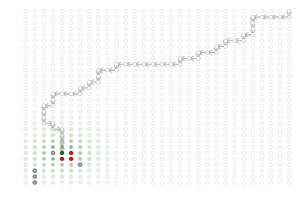

```julia
let

    # initialize -
    p = plot();
    initial_site = startstate
    hit_absorbing_state = false
    s = world_model.states[initial_site];
    visited_sites = Set{Tuple{Int,Int}}();
    push!(visited_sites, initial_site);

    while (hit_absorbing_state == false)
        current_position = world_model.coordinates[s]
        a = my_π[s];
        Δ = world_model.moves[a];
        new_position =  current_position .+ Δ
        scatter!([current_position[1]],[current_position[2]], label="", showaxis=:false, msc=:black, c=:blue)
        plot!([current_position[1], new_position[1]],[current_position[2],new_position[2]], label="", arrow=true, lw=1, c=:gray)

        if (in(new_position, absorbing_state_set) == true || in(new_position, visited_sites) == true)
            hit_absorbing_state = true;
        elseif (haskey(world_model.states, new_position) == true)
            s = world_model.states[new_position];
            push!(visited_sites, new_position);
        else
            hit_absorbing_state = true; # we drove off the map
        end
    end

    # draw the grid -
    for s ∈ 𝒮
        current_position = world_model.coordinates[s]
        a = my_π[s];
        Δ = world_model.moves[a];
        new_position =  current_position .+ Δ

        if (haskey(rewards, current_position) == true && rewards[current_position] == charging_reward)
            scatter!([current_position[1]],[current_position[2]], label="", showaxis=:false, c=:green, ms=4)
        elseif (haskey(rewards, current_position) == true && rewards[current_position] == lava_reward)
            scatter!([current_position[1]],[current_position[2]], label="", showaxis=:false, c=:red, ms=4)
        elseif (in(current_position, soft_wall_set) == true)
            scatter!([current_position[1]],[current_position[2]], label="", showaxis=:false, c=:gray69, ms=4)
        else
            if (is_reward_shaping_on == true)
                new_color = weighted_color_mean(rbf(current_position, (5,6), σ = σ), colorant"green", colorant"white")
                scatter!([current_position[1]],[current_position[2]], label="", showaxis=:false, msc=:lightgray, c=new_color)
            else
                scatter!([current_position[1]],[current_position[2]], label="", showaxis=:false, msc=:black, c=:white)
            end
        end
    end
    current()
end
```

## Summary

In this activity, we used Q-learning to train a robot to navigate a grid world with obstacles, rewards, and penalties.

> **Key Takeaways:**
> - **Model-free learning:** Q-learning does not require knowledge of the environment dynamics. The agent learns by interacting with the environment and observing rewards, making it suitable for problems where the transition model is unknown.
> - **Action-value function:** The algorithm builds a Q-table that estimates the expected return for each state-action pair. The policy is derived by selecting the action with the highest Q-value in each state.
> - **Reward shaping accelerates learning:** In environments with sparse rewards, shaping techniques like radial basis functions provide additional guidance signals that help the agent discover productive behaviors more quickly.

Q-learning enables agents to learn optimal policies through experience without requiring a model of the environment. ___